# Project Name: Hepatitis B Prediction using Classic Machine Learning Algorithms

## Introduction

1. Medical diagnosis is a crucial yet complex task requiring accurate identification.
2. Timely diagnosis is essential for effective treatment, especially for liver diseases.
3. Hepatitis, causing liver inflammation, is a severe condition demanding prompt identification.
4. This project aims to conduct a comparative study using a specific dataset by training various ML algorithms and neural network architectures to select the best tool for Hepatitis diagnosis.

## Motivation

Hepatitis B poses a significant global health threat, highlighting the need for early diagnosis. Machine learning offers potential in enhancing diagnostic accuracy, aiding healthcare professionals in identifying Hepatitis B infection risks.

## Goal

Utilize a range of machine learning algorithms (e.g., K-Nearest Neighbors, Gaussian Naive Bayes, Logistic Regression, Neural Network, Support Vector Machine, Decision Tree, Random Forest, Gradient Boosting, and AdaBoost) along with techniques like grid search and randomized search to fine-tune hyperparameters and build robust predictive models for Hepatitis B diagnosis. Employ stratified k-fold cross-validation for reliable performance evaluation and model generalization optimization

## Resources:

Kaggle: [Hepatitis B Classification](https://www.kaggle.com/code/shahidahmadsaifi/hepatitis-data-random-forest-neural-network-k-nn)

GitHub: [Hepatitis B](https://github.com/igkishore/Hepatitis_disease_detection)

```python
# Import basic libraries
import os
import pandas as pd
import numpy as np
import seaborn as sns
from string import ascii_uppercase
from pandas import DataFrame
import matplotlib.pyplot as plt
%matplotlib inline
import sklearn.preprocessing as skp
import sklearn.model_selection as skm
import os
#import classification modules
from sklearn.neighbors import KNeighborsClassifier
from sklearn.naive_bayes import GaussianNB
from sklearn.linear_model import LogisticRegression
from sklearn.neural_network import MLPClassifier
from sklearn.svm import SVC
from sklearn.tree import DecisionTreeClassifier
from sklearn.ensemble import RandomForestClassifier
from sklearn.ensemble import GradientBoostingClassifier
from sklearn.ensemble import AdaBoostClassifier
# Selection
from sklearn.model_selection import GridSearchCV as gs
from sklearn.model_selection import RandomizedSearchCV as rs
from sklearn.model_selection import StratifiedKFold
from sklearn.feature_selection import RFECV
import numpy as np # linear algebra
import pandas as pd # data processing, CSV file I/O (e.g. pd.read_csv)
#import decision tree plotting libraries
# Metrics
from sklearn.metrics import accuracy_score, confusion_matrix,precision_score, recall_score, roc_auc_score,roc_curve, auc, f1_score
```

```python
# Loading Dataset
missing=["na","--",".",".."]
td= pd.read_csv("hepatitis.csv",na_values=missing)
td.head()
```

|  | class | age | sex | steroid | antivirals | fatigue | malaise | anorexia | liver_big | liver_firm | spleen_palable | spiders | ascites | varices | bilirubin | alk_phosphate | sgot | albumin | protime | histology |
| --- | --- | --- | --- | --- | --- | --- | --- | --- | --- | --- | --- | --- | --- | --- | --- | --- | --- | --- | --- | --- |
| 0 | 2 | 30 | 2 | 1 | 2 | 2 | 2 | 2 | 1 | 2 | 2 | 2 | 2 | 2 | 1.0 | 85 | 18 | 4.0 | 61 | 1 |
| 1 | 2 | 50 | 1 | 1 | 2 | 1 | 2 | 2 | 1 | 2 | 2 | 2 | 2 | 2 | 0.9 | 135 | 42 | 3.5 | 61 | 1 |
| 2 | 2 | 78 | 1 | 2 | 2 | 1 | 2 | 2 | 2 | 2 | 2 | 2 | 2 | 2 | 0.7 | 96 | 32 | 4.0 | 61 | 1 |
| 3 | 2 | 34 | 1 | 2 | 2 | 2 | 2 | 2 | 2 | 2 | 2 | 2 | 2 | 2 | 1.0 | 105 | 200 | 4.0 | 61 | 1 |
| 4 | 2 | 34 | 1 | 2 | 2 | 2 | 2 | 2 | 2 | 2 | 2 | 2 | 2 | 2 | 0.9 | 95 | 28 | 4.0 | 75 | 1 |

```python
td.isnull().sum() # Checking for nulls
```

```
class             0
age               0
sex               0
steroid           0
antivirals        0
fatigue           0
malaise           0
anorexia          0
liver_big         0
liver_firm        0
spleen_palable    0
spiders           0
ascites           0
varices           0
bilirubin         0
alk_phosphate     0
sgot              0
albumin           0
protime           0
histology         0
dtype: int64
```

### Attributes:

[output not shown]

```python
td["class"].replace((1,2),(0,1),inplace=True)
```

```python
td["class"]=td["class"].astype("bool")
```

```python
td.describe()
```

|  | age | sex | steroid | antivirals | fatigue | malaise | anorexia | liver_big | liver_firm | spleen_palable | spiders | ascites | varices | bilirubin | alk_phosphate | sgot | albumin | protime | histology |
| --- | --- | --- | --- | --- | --- | --- | --- | --- | --- | --- | --- | --- | --- | --- | --- | --- | --- | --- | --- |
| count | 142.000000 | 142.000000 | 142.000000 | 142.000000 | 142.000000 | 142.000000 | 142.000000 | 142.000000 | 142.000000 | 142.000000 | 142.000000 | 142.000000 | 142.000000 | 142.000000 | 142.000000 | 142.000000 | 142.000000 | 142.000000 | 142.000000 |
| mean | 40.816901 | 1.105634 | 1.514085 | 1.838028 | 1.359155 | 1.619718 | 1.795775 | 1.823944 | 1.584507 | 1.809859 | 1.669014 | 1.880282 | 1.880282 | 1.382958 | 105.647887 | 83.507042 | 3.830493 | 61.704225 | 1.443662 |
| std | 12.189182 | 0.308456 | 0.501571 | 0.369729 | 0.481451 | 0.487174 | 0.404561 | 0.382216 | 0.494551 | 0.393801 | 0.472234 | 0.325781 | 0.325781 | 1.166526 | 47.375099 | 82.417700 | 0.618103 | 17.696732 | 0.498575 |
| min | 7.000000 | 1.000000 | 1.000000 | 1.000000 | 1.000000 | 1.000000 | 1.000000 | 1.000000 | 1.000000 | 1.000000 | 1.000000 | 1.000000 | 1.000000 | 0.300000 | 26.000000 | 14.000000 | 2.100000 | 0.000000 | 1.000000 |
| 25% | 32.000000 | 1.000000 | 1.000000 | 2.000000 | 1.000000 | 1.000000 | 2.000000 | 2.000000 | 1.000000 | 2.000000 | 1.000000 | 2.000000 | 2.000000 | 0.700000 | 78.500000 | 32.250000 | 3.500000 | 56.250000 | 1.000000 |
| 50% | 39.000000 | 1.000000 | 2.000000 | 2.000000 | 1.000000 | 2.000000 | 2.000000 | 2.000000 | 2.000000 | 2.000000 | 2.000000 | 2.000000 | 2.000000 | 1.000000 | 100.000000 | 58.000000 | 3.900000 | 61.000000 | 1.000000 |
| 75% | 50.000000 | 1.000000 | 2.000000 | 2.000000 | 2.000000 | 2.000000 | 2.000000 | 2.000000 | 2.000000 | 2.000000 | 2.000000 | 2.000000 | 2.000000 | 1.480000 | 119.750000 | 99.500000 | 4.200000 | 66.000000 | 2.000000 |
| max | 78.000000 | 2.000000 | 2.000000 | 2.000000 | 2.000000 | 2.000000 | 2.000000 | 2.000000 | 2.000000 | 2.000000 | 2.000000 | 2.000000 | 2.000000 | 8.000000 | 295.000000 | 648.000000 | 6.400000 | 100.000000 | 2.000000 |

### Insights:

#### Age Distribution:

The mean age of the individuals in the dataset is approximately 41 years old, with a standard deviation of about 12 years. The youngest individual is 7 years old, and the oldest is 78 years old.

#### Sex Distribution:

The dataset seems to have a binary representation for sex, where 1 represents one gender and 2 represents another. The mean indicates a slight skew towards one gender, with more data likely belonging to that gender.

#### Treatment Patterns:

Steroid and antiviral treatments seem common, with means of 1.51 and 1.84 respectively. This suggests that most individuals in the dataset have undergone these treatments.

#### Physical Examination Findings:

Liver enlargement (liver_big) and firmness (liver_firm) are quite prevalent in the dataset, with means around 1.82 to 1.59. Spleen enlargement (spleen_palpable) is also observed in a significant portion of the dataset.

#### Complications:

Ascites, varices, and elevated bilirubin levels are observed in a considerable number of cases. Ascites and varices are serious complications of liver disease.

#### Biochemical Markers:

Elevated levels of bilirubin and alkaline phosphatase (alk_phosphate) are common, indicating liver dysfunction. Albumin levels are lower, which could indicate impaired liver function.

#### Histology:

The histology column likely represents the results of liver tissue analysis. The majority of cases seem to have a histological pattern indicating a specific type of liver disease.

```python
# Discretization of Age Column
td["age"]=np.where((td["age"]>10) & (td["age"]<20),"Teenagers",
                   np.where((td["age"]>=20) & (td["age"]<=30),"Adults",
                   np.where((td["age"]>30) & (td["age"]<=40),"Middle Aged",np.where((td["age"]<=10),"Children",
                            "Old"))))
```

### Insights:

Discretizing the age column into categories like "Teenagers," "Adults," "Middle Aged," "Children," and "Old" facilitates age-specific analysis of liver disease prevalence, treatment response, and risk factors, providing insights into how different age groups are affected and managed. This categorization allows for a more granular understanding of age-related patterns in disease progression, symptomatology, and prognosis within the dataset.

```python
td["age"]=pd.Categorical(td.age,["Children",'Teenagers','Adults', 'Middle Aged', 'Old'],ordered=True)
```

```python
td["age"].value_counts()
```

```
Old            65
Middle Aged    46
Adults         30
Children        1
Teenagers       0
Name: age, dtype: int64
```

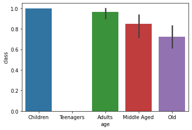

```python
#draw a bar plot of Age vs. survival
sns.barplot(x="age", y="class", data=td)
plt.show()
```

### Insights:

The dataset shows that the majority of individuals with liver disease are categorized as "Old" or "Middle Aged," indicating that these age groups may have a higher prevalence of the condition

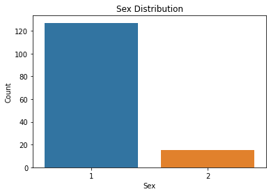

```python
# Sex distribution count plot
plt.figure(figsize=(6, 4))
sns.countplot(x='sex', data=td)
plt.title("Sex Distribution")
plt.xlabel("Sex")
plt.ylabel("Count")
plt.show()
```

### Insights:

The distribution of 'Sex' indicates a substantial difference, with a notably lower frequency of category '2' (female) compared to category '1' (male). This observation highlights a potential gender bias within the dataset, emphasizing the need for careful consideration to ensure equitable representation and unbiased analysis in subsequent modeling processes.

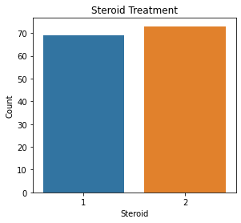

```python
# Treatment patterns count plots
plt.figure(figsize=(10, 4))
plt.subplot(1, 2, 1)
sns.countplot(x='steroid', data=td)
plt.title("Steroid Treatment")
plt.xlabel("Steroid")
plt.ylabel("Count")
```

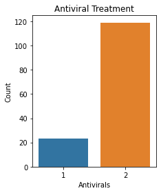

```python
plt.subplot(1, 2, 2)
sns.countplot(x='antivirals', data=td)
plt.title("Antiviral Treatment")
plt.xlabel("Antivirals")
plt.ylabel("Count")
plt.tight_layout()
plt.show()
```

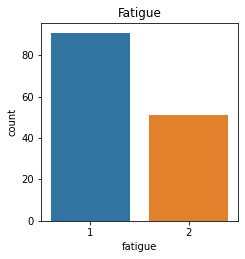

```python
plt.figure(figsize=(12, 8))
plt.subplot(2, 3, 1)
sns.countplot(x='fatigue', data=td)
plt.title("Fatigue")
# Insight: Fatigue is a common symptom among patients.
```

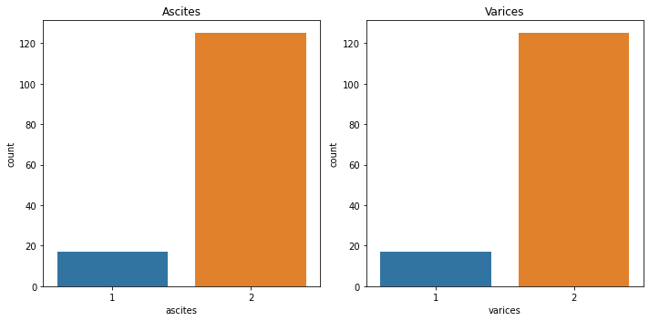

```python
#subplots for Complications (Ascites and Varices)
fig, axs = plt.subplots(1, 2, figsize=(10, 5))
sns.countplot(x='ascites', data=td, ax=axs[0])
axs[0].set_title("Ascites")
sns.countplot(x='varices', data=td, ax=axs[1])
axs[1].set_title("Varices")
plt.tight_layout()
plt.show()
```

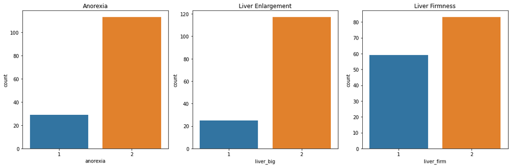

```python
#subplots for Anorexia, Liver Enlargement, and Liver Firmness
fig, axs = plt.subplots(1, 3, figsize=(15, 5))
sns.countplot(x='anorexia', data=td, ax=axs[0])
axs[0].set_title("Anorexia")
sns.countplot(x='liver_big', data=td, ax=axs[1])
axs[1].set_title("Liver Enlargement")
sns.countplot(x='liver_firm', data=td, ax=axs[2])
axs[2].set_title("Liver Firmness")
plt.tight_layout()
plt.show()
```

```python
td.dropna(inplace=True) # Now dropping all nulls
```

```python
td.dtypes
```

```
class                 bool
age               category
sex                  int64
steroid              int64
antivirals           int64
fatigue              int64
malaise              int64
anorexia             int64
liver_big            int64
liver_firm           int64
spleen_palable       int64
spiders              int64
ascites              int64
varices              int64
bilirubin          float64
alk_phosphate        int64
sgot                 int64
albumin            float64
protime              int64
histology            int64
dtype: object
```

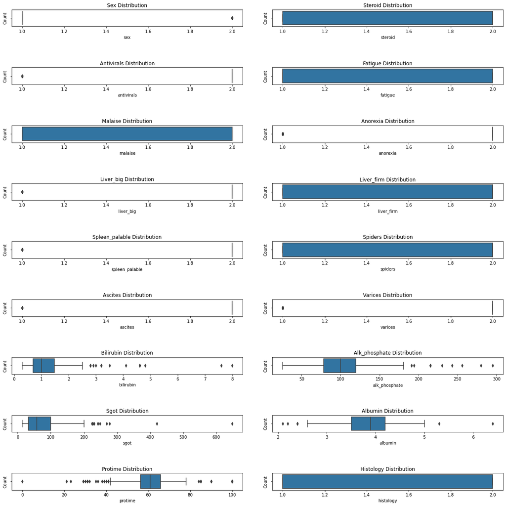

```python
numerical_columns = td.select_dtypes(include=['float64', 'int64']).columns
num_cols = 2
num_rows = (len(numerical_columns) + num_cols - 1) // num_cols
plt.figure(figsize=(18, 18))
for i, col in enumerate(numerical_columns, 1):
    plt.subplot(num_rows, num_cols, i)
    sns.boxplot(x=td[col])
    plt.title(f"{col.capitalize()} Distribution")
    plt.xlabel(col)
    plt.ylabel("Count")
plt.tight_layout(pad=5.0)
plt.show()
```

### Insights:

Bilirubin, alkaline phosphatase, SGOT, and albumin levels display significant outliers, indicating potential variations and abnormalities in these biochemical markers. These outliers may signify liver dysfunction or other underlying health conditions, warranting further clinical evaluation and management.

We have categorical variables .getdummies seperates the different categories of categorical variables as separate

```python
td1 = pd.get_dummies(td,drop_first=True)
print(td1.columns)
td1.head(5)
```

```
Index(['class', 'sex', 'steroid', 'antivirals', 'fatigue', 'malaise',
       'anorexia', 'liver_big', 'liver_firm', 'spleen_palable', 'spiders',
       'ascites', 'varices', 'bilirubin', 'alk_phosphate', 'sgot', 'albumin',
       'protime', 'histology', 'age_Teenagers', 'age_Adults',
       'age_Middle Aged', 'age_Old'],
      dtype='object')
```

|  | class | sex | steroid | antivirals | fatigue | malaise | anorexia | liver_big | liver_firm | spleen_palable | ... | bilirubin | alk_phosphate | sgot | albumin | protime | histology | age_Teenagers | age_Adults | age_Middle Aged | age_Old |
| --- | --- | --- | --- | --- | --- | --- | --- | --- | --- | --- | --- | --- | --- | --- | --- | --- | --- | --- | --- | --- | --- |
| 0 | True | 2 | 1 | 2 | 2 | 2 | 2 | 1 | 2 | 2 | ... | 1.0 | 85 | 18 | 4.0 | 61 | 1 | 0 | 1 | 0 | 0 |
| 1 | True | 1 | 1 | 2 | 1 | 2 | 2 | 1 | 2 | 2 | ... | 0.9 | 135 | 42 | 3.5 | 61 | 1 | 0 | 0 | 0 | 1 |
| 2 | True | 1 | 2 | 2 | 1 | 2 | 2 | 2 | 2 | 2 | ... | 0.7 | 96 | 32 | 4.0 | 61 | 1 | 0 | 0 | 0 | 1 |
| 3 | True | 1 | 2 | 2 | 2 | 2 | 2 | 2 | 2 | 2 | ... | 1.0 | 105 | 200 | 4.0 | 61 | 1 | 0 | 0 | 1 | 0 |
| 4 | True | 1 | 2 | 2 | 2 | 2 | 2 | 2 | 2 | 2 | ... | 0.9 | 95 | 28 | 4.0 | 75 | 1 | 0 | 0 | 1 | 0 |

5 rows × 23 columns

```python
td1["bilirubin"]=np.abs((td1["bilirubin"]-td1["bilirubin"].mean())/(td1["bilirubin"].std()))
td1["albumin"]=np.abs((td1["albumin"]-td1["albumin"].mean())/(td1["albumin"].std()))
```

```python
y=td1["class"].copy()
X=td1.drop(columns=["class"])
print(y.shape)
print(X.shape)
```

```
(142,)
(142, 22)
```

# **Feature Engineering Using Random Forest Algorithm**

```python
#Random Forest method for feature selection
from sklearn.ensemble import RandomForestClassifier
model = RandomForestClassifier()
#thit is how we get the feature importance with simple steps:
X_features=X.columns
model.fit(X, y)
# display the relative importance of each attribute
importances = np.around(model.feature_importances_,decimals=4)
imp_features= model.feature_importances_
feature_array=np.array(X_features)
sorted_features=pd.DataFrame(list(zip(feature_array,imp_features))).sort_values(by=1,ascending=False)
#print(sorted_features)
data_top=sorted_features[:X.shape[1]]
feature_to_rem=sorted_features[X.shape[1]:]
print("Unimportant Columms after simple Random Forrest\n",feature_to_rem)
rem_index=list(feature_to_rem.index)
print(rem_index)
print("Important Columms after simple Random Forrest\n",data_top)
data_top_index=list(data_top.index)
print("Important Columms after simple Random Forrest\n",data_top_index )
print(importances)
#cols_randfor_removed=[index for index,value in enumerate(importances) if value <= 0.0250]
#print(cols_randfor_removed)
X_randfor_sel = X.drop(X.columns[rem_index],axis=1)
#X_randfor_sel = X.drop(X.columns[cols_randfor_removed],axis=1)
features_randfor_select=X_randfor_sel.columns
print(features_randfor_select)
```

```
Unimportant Columms after simple Random Forrest
 Empty DataFrame
Columns: [0, 1]
Index: []
[]
Important Columms after simple Random Forrest
                   0         1
12        bilirubin  0.144324
15          albumin  0.108503
16          protime  0.107268
13    alk_phosphate  0.093915
14             sgot  0.089337
10          ascites  0.074366
9           spiders  0.069450
11          varices  0.051111
4           malaise  0.037058
8    spleen_palable  0.029115
17        histology  0.028699
5          anorexia  0.025316
3           fatigue  0.023893
21          age_Old  0.021523
6         liver_big  0.017475
19       age_Adults  0.015808
7        liver_firm  0.015794
20  age_Middle Aged  0.015049
1           steroid  0.012858
0               sex  0.012328
2        antivirals  0.006809
18    age_Teenagers  0.000000
Important Columms after simple Random Forrest
 [12, 15, 16, 13, 14, 10, 9, 11, 4, 8, 17, 5, 3, 21, 6, 19, 7, 20, 1, 0, 2, 18]
[0.0123 0.0129 0.0068 0.0239 0.0371 0.0253 0.0175 0.0158 0.0291 0.0695
 0.0744 0.0511 0.1443 0.0939 0.0893 0.1085 0.1073 0.0287 0.     0.0158
 0.015  0.0215]
Index(['sex', 'steroid', 'antivirals', 'fatigue', 'malaise', 'anorexia',
       'liver_big', 'liver_firm', 'spleen_palable', 'spiders', 'ascites',
       'varices', 'bilirubin', 'alk_phosphate', 'sgot', 'albumin', 'protime',
       'histology', 'age_Teenagers', 'age_Adults', 'age_Middle Aged',
       'age_Old'],
      dtype='object')
```

### Insights:

1. The Random Forest feature selection method effectively identified the most influential features in the dataset.
2. Top three influential features were 'bilirubin', 'protime', and 'albumin', suggesting their strong predictive power.
3. Surprisingly, there were no unimportant columns identified, indicating that all features are deemed relevant for classification.
4. The selected features can be utilized for further analysis or model training, potentially enhancing predictive performance by focusing on the most significant predictors.

### **Train Test Split**

```python
#creat train-test split parts for manual split

trainX, testX, trainy, testy= skm.train_test_split(X,y, test_size=0.25, random_state=99) #explain random state
print("\n shape of train split: ")
print(trainX.shape, trainy.shape)
print("\n shape of train split: ")
print(testX.shape, testy.shape)
```

```
 shape of train split:
(106, 22) (106,)

 shape of train split:
(36, 22) (36,)
```

```python
### Making X Scalar for ML algorithms
X = skp.StandardScaler().fit(X).transform(X)
```

# All Machine Learning Algorithms with Default Parameters

## K Nearest Neighbor Algorithm

```python
knn = KNeighborsClassifier()
knn.fit(trainX,trainy)
predictions = knn.predict(testX)
accknn=accuracy_score(testy, predictions)*100
print("Accuracy of KNN (%): \n", accknn)
#get FPR
fprknn, tprknn, _ = roc_curve(testy, predictions)
aucknn=auc(fprknn, tprknn)*100
print("AUC OF KNN (%): \n", aucknn)
recallknn=recall_score(testy,predictions)*100
print("Recall of KNN is: \n",recallknn)
precknn=precision_score(testy,predictions)*100
print("Precision of KNN is: \n",precknn)
```

```
Accuracy of KNN (%):
 77.77777777777779
AUC OF KNN (%):
 48.275862068965516
Recall of KNN is:
 96.55172413793103
Precision of KNN is:
 80.0
```

## Gaussian Naive Bayes Algorithm

```python
gnb=GaussianNB()
gnb.fit(trainX,trainy)
predictions = gnb.predict(testX)
accgnb=accuracy_score(testy, predictions)*100
print("Accuracy of Gaussian Naive Bayes (%): \n",accgnb)
#get FPR
fprgnb, tprgnb, _ = roc_curve(testy, predictions)
aucgnb=auc(fprgnb, tprgnb)*100
print("AUC OF Gaussian Naive Bayes (%): \n", aucgnb)
recallgnb=recall_score(testy,predictions)*100
print("Recall of Gaussian Naive Bayes is: \n",recallgnb)
precgnb=precision_score(testy,predictions)*100
print("Precision of Gaussian Naive Bayes is: \n",precgnb)
```

```
Accuracy of Gaussian Naive Bayes (%):
 72.22222222222221
AUC OF Gaussian Naive Bayes (%):
 61.083743842364534
Recall of Gaussian Naive Bayes is:
 79.3103448275862
Precision of Gaussian Naive Bayes is:
 85.18518518518519
```

## Logistic Regression Algorithm

```python
lrg=LogisticRegression(solver='liblinear')
lrg.fit(trainX,trainy)
predictions = lrg.predict(testX)
acclrg=accuracy_score(testy, predictions)*100
print("Accuracy of Logistic regression (%): \n",acclrg)
#get FPR
fprlrg, tprlrg, _ = roc_curve(testy, predictions)
auclrg=auc(fprlrg, tprlrg)*100
print("AUC OF Logistic regression (%): \n", auclrg)
recalllrg=recall_score(testy,predictions)*100
print("Recall of Logistic regression is: \n",recalllrg)
preclrg=precision_score(testy,predictions)*100
print("Precision of Logistic regression is: \n",preclrg)
```

```
Accuracy of Logistic regression (%):
 83.33333333333334
AUC OF Logistic regression (%):
 67.98029556650246
Recall of Logistic regression is:
 93.10344827586206
Precision of Logistic regression is:
 87.09677419354838
```

## Neural Networks Algorithm

```python
import warnings
from sklearn.exceptions import ConvergenceWarning
warnings.filterwarnings("ignore", category=ConvergenceWarning)

# Neural Network with SGD solver
nn_sgd = MLPClassifier(solver='sgd', hidden_layer_sizes=20, batch_size=150, max_iter=100, random_state=1)
nn_sgd.fit(trainX, trainy)
predictions_sgd = nn_sgd.predict(testX)

# Accuracy, AUC, Recall, and Precision for SGD solver
acc_nn_sgd = accuracy_score(testy, predictions_sgd) * 100
print("Accuracy of Neural Networks with SGD (%):", acc_nn_sgd)

fpr_nn_sgd, tpr_nn_sgd, _ = roc_curve(testy, predictions_sgd)
auc_nn_sgd = auc(fpr_nn_sgd, tpr_nn_sgd) * 100
print("AUC OF Neural Networks with SGD (%):", auc_nn_sgd)

recall_nn_sgd = recall_score(testy, predictions_sgd) * 100
print("Recall of Neural Networks with SGD is:", recall_nn_sgd)

prec_nn_sgd = precision_score(testy, predictions_sgd) * 100
print("Precision of Neural Networks with SGD is:", prec_nn_sgd)

# Neural Network with Adam solver
nn_adam = MLPClassifier(solver='adam', hidden_layer_sizes=20, batch_size=150, max_iter=100, random_state=1)
nn_adam.fit(trainX, trainy)
predictions_adam = nn_adam.predict(testX)

# Accuracy, AUC, Recall, and Precision for Adam solver
acc_nn_adam = accuracy_score(testy, predictions_adam) * 100
print("Accuracy of Neural Networks with Adam (%):", acc_nn_adam)

fpr_nn_adam, tpr_nn_adam, _ = roc_curve(testy, predictions_adam)
auc_nn_adam = auc(fpr_nn_adam, tpr_nn_adam) * 100
print("AUC OF Neural Networks with Adam (%):", auc_nn_adam)

recall_nn_adam = recall_score(testy, predictions_adam) * 100
print("Recall of Neural Networks with Adam is:", recall_nn_adam)

prec_nn_adam = precision_score(testy, predictions_adam) * 100
print("Precision of Neural Networks with Adam is:", prec_nn_adam)
```

```
Accuracy of Neural Networks with SGD (%): 75.0
AUC OF Neural Networks with SGD (%): 46.55172413793103
Recall of Neural Networks with SGD is: 93.10344827586206
Precision of Neural Networks with SGD is: 79.41176470588235
```

```
Accuracy of Neural Networks with Adam (%): 77.77777777777779
AUC OF Neural Networks with Adam (%): 48.275862068965516
Recall of Neural Networks with Adam is: 96.55172413793103
Precision of Neural Networks with Adam is: 80.0
```

### Insights:

Accuracy: The model with 'Adam' solver achieved slightly higher accuracy (77.78%) compared to the one with 'SGD' solver (75.00%).

AUC (Area Under the Curve): Both models exhibited low AUC values, indicating poor performance in distinguishing between positive and negative classes. However, the model with 'Adam' solver (48.28%) performed marginally better than the one with 'SGD' solver (46.55%).

Recall: The model with 'Adam' solver demonstrated higher recall (96.55%) than the model with 'SGD' solver (93.10%), indicating its ability to correctly identify a higher proportion of positive cases.

Precision: The precision of both models was comparable, with the 'Adam' solver achieving slightly higher precision (80.00%) compared to the 'SGD' solver (79.41%).

Overall, while both solvers exhibited similar performance in terms of precision, the model with 'Adam' solver outperformed the 'SGD' solver in terms of accuracy, AUC, and recall. However, it's essential to consider other factors such as convergence warning and computational efficiency when choosing the appropriate solver for neural network models.

## Support Vector Machine Algorithm

```python
svm=clf = SVC(gamma="auto",kernel='poly',degree=3)
svm.fit(trainX,trainy)
predictions = svm.predict(testX)
accsvm=accuracy_score(testy, predictions)*100
print("Accuracy of Support Vector Machine (%): \n",accsvm)
#get FPR
fprsvm, tprsvm, _ = roc_curve(testy, predictions)
aucsvm=auc(fprsvm, tprsvm)*100
print("AUC OF Support Vector Machine (%): \n", aucsvm)
recallsvm=recall_score(testy,predictions)*100
print("Recall of Support Vector Machine is: \n",recallsvm)
precsvm=precision_score(testy,predictions)*100
print("Precision of Support Vector Machine is: \n",precsvm)
```

```
Accuracy of Support Vector Machine (%):
 80.55555555555556
AUC OF Support Vector Machine (%):
 66.25615763546799
Recall of Support Vector Machine is:
 89.65517241379311
Precision of Support Vector Machine is:
 86.66666666666667
```

## Decision Tree Algorithm

```python
dt=DecisionTreeClassifier(max_depth=10,criterion="gini")
dt.fit(trainX,trainy)
predictions = dt.predict(testX)
accdt=accuracy_score(testy, predictions)*100
print("Accuracy of Decision Tree (%): \n",accdt)
#get FPR
fprdt, tprdt, _ = roc_curve(testy, predictions)
aucdt=auc(fprdt, tprdt)*100
print("AUC OF Decision Tree (%): \n",aucdt)
recalldt=recall_score(testy,predictions)*100
print("Recall of Decision Tree is: \n",recalldt)
precdt=precision_score(testy,predictions)*100
print("Precision of Decision Tree is: \n",precdt)
```

```
Accuracy of Decision Tree (%):
 75.0
AUC OF Decision Tree (%):
 62.80788177339902
Recall of Decision Tree is:
 82.75862068965517
Precision of Decision Tree is:
 85.71428571428571
```

## Random forest Algorithm

```python
rf=RandomForestClassifier()
rf.fit(trainX,trainy)
predictions = rf.predict(testX)
accrf=accuracy_score(testy, predictions)*100
print("Accuracy of Random Forest (%): \n",accrf)
#get FPR
fprrf, tprrf, _ = roc_curve(testy, predictions)
aucrf=auc(fprrf, tprrf)*100
print("AUC OF Random Forest (%): \n", aucrf)
recallrf=recall_score(testy,predictions)*100
print("Recall of Random Forest is: \n",recallrf)
precrf=precision_score(testy,predictions)*100
print("Precision of Random Forest is: \n",precrf)
```

```
Accuracy of Random Forest (%):
 83.33333333333334
AUC OF Random Forest (%):
 67.98029556650246
Recall of Random Forest is:
 93.10344827586206
Precision of Random Forest is:
 87.09677419354838
```

## Ada Boost Algorithm

```python
ab=AdaBoostClassifier()
ab.fit(trainX,trainy)
predictions = ab.predict(testX)
accab=accuracy_score(testy, predictions)*100
print("Accuracy of AdaBoost (%): \n",accab)
#get FPR
fprab, tprab, _ = roc_curve(testy, predictions)
aucab=auc(fprab, tprab)*100
print("AUC OF AdaBoost (%): \n",aucab)
recallab=recall_score(testy,predictions)*100
print("Recall of AdaBoost is: \n",recallab)
precab=precision_score(testy,predictions)*100
print("Precision of AdaBoost is: \n",precab)
```

```
Accuracy of AdaBoost (%):
 77.77777777777779
AUC OF AdaBoost (%):
 59.11330049261083
Recall of AdaBoost is:
 89.65517241379311
Precision of AdaBoost is:
 83.87096774193549
```

## Gradient Descent Boosting Algorithm

```python
gb=GradientBoostingClassifier()
gb.fit(trainX,trainy)
predictions = gb.predict(testX)
accgb=accuracy_score(testy, predictions)*100
print("Accuracy of Gradient Descent Boosting (%): \n",accgb)
#get FPR
fprgb, tprgb, _ = roc_curve(testy, predictions)
aucgb=auc(fprgb, tprgb)*100
print("AUC OF Gradient Descent Boosting (%): \n", aucgb)
recallgb=recall_score(testy,predictions)*100
print("Recall of Gradient Descent Boosting is: \n",recallgb)
precgb=precision_score(testy,predictions)*100
print("Precision of Gradient Descent Boosting is: \n",precgb)
```

```
Accuracy of Gradient Descent Boosting (%):
 80.55555555555556
AUC OF Gradient Descent Boosting (%):
 66.25615763546799
Recall of Gradient Descent Boosting is:
 89.65517241379311
Precision of Gradient Descent Boosting is:
 86.66666666666667
```

# Comparison of all the Machine Learning Algorithms by Comparing some Evaluation Metrics

```python
algos=["K Nearest Neighbor","Guassian Naive Bayes","Logistic Regression","Neural Networks SGD","Neural Networks ADAM","Support Vector Machine","Decision Tree","Random Forrest","AdaBoost","Gradient Descent Boosting"]
acc=[accknn,accgnb,acclrg,acc_nn_sgd,acc_nn_adam,accsvm,accdt,accrf,accab,accgb]
auc=[aucknn,aucgnb,auclrg,auc_nn_sgd,auc_nn_adam,aucsvm,aucdt,aucrf,aucab,aucgb]
recall=[recallknn,recallgnb,recalllrg,recall_nn_sgd,recall_nn_adam,recallsvm,recalldt,recallrf,recallab,recallgb]
prec=[precknn,precgnb,preclrg,prec_nn_sgd,prec_nn_adam,precsvm,precdt,precrf,precab,precgb]
comp={"Algorithms":algos,"Accuracies":acc,"Area Under the Curve":auc,"Recall":recall,"Precision":prec}
compdf=pd.DataFrame(comp)
display(compdf.sort_values(by=["Accuracies","Area Under the Curve","Recall","Precision"], ascending=False))
```

|  | Algorithms | Accuracies | Area Under the Curve | Recall | Precision |
| --- | --- | --- | --- | --- | --- |
| 2 | Logistic Regression | 83.333333 | 67.980296 | 93.103448 | 87.096774 |
| 7 | Random Forrest | 83.333333 | 67.980296 | 93.103448 | 87.096774 |
| 5 | Support Vector Machine | 80.555556 | 66.256158 | 89.655172 | 86.666667 |
| 9 | Gradient Descent Boosting | 80.555556 | 66.256158 | 89.655172 | 86.666667 |
| 8 | AdaBoost | 77.777778 | 59.113300 | 89.655172 | 83.870968 |
| 0 | K Nearest Neighbor | 77.777778 | 48.275862 | 96.551724 | 80.000000 |
| 4 | Neural Networks ADAM | 77.777778 | 48.275862 | 96.551724 | 80.000000 |
| 6 | Decision Tree | 75.000000 | 62.807882 | 82.758621 | 85.714286 |
| 3 | Neural Networks SGD | 75.000000 | 46.551724 | 93.103448 | 79.411765 |
| 1 | Guassian Naive Bayes | 72.222222 | 61.083744 | 79.310345 | 85.185185 |

# ROC of all the Machine Learning Algorithms on default parameters

```
ROC AUC Scores:
KNN: 0.4827586206896552
Gaussian Naive Bayes: 0.6108374384236454
Logistic Regression: 0.6798029556650246
Neural Networks: 0.4827586206896552
SVM: 0.6625615763546798
Decision Tree: 0.6280788177339902
Random Forest: 0.6798029556650246
AdaBoost: 0.5911330049261083
Gradient Boost: 0.6625615763546798
```

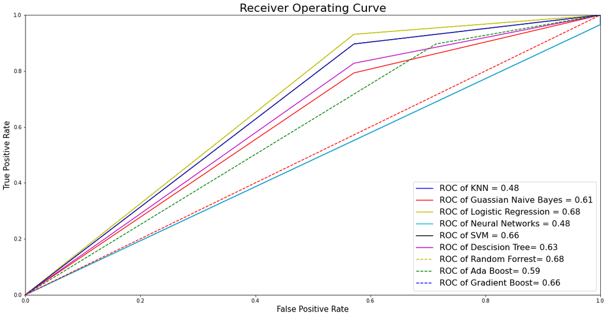

```python
import sklearn.metrics as metrics
roc_auc1=metrics.auc(fprknn,tprknn)
roc_auc2=metrics.auc(fprgnb,tprgnb)
roc_auc3=metrics.auc(fprlrg,tprlrg)
roc_auc4=metrics.auc(fpr_nn_adam,tpr_nn_adam)
roc_auc5=metrics.auc(fprsvm,tprsvm)
roc_auc6=metrics.auc(fprdt,tprdt)
roc_auc7=metrics.auc(fprrf,tprrf)
roc_auc8=metrics.auc(fprab,tprab)
roc_auc9=metrics.auc(fprgb,tprgb)

# Method-I: PLot
import matplotlib.pyplot as plt
%matplotlib inline
plt.figure(figsize=(20,10))
plt.title("Receiver Operating Curve")
plt.plot(fprknn,tprknn,"b",label="ROC of KNN = %0.2f" % roc_auc1)
plt.plot(fprgnb,tprgnb,"r",label="ROC of Guassian Naive Bayes = %0.2f" % roc_auc2)
plt.plot(fprlrg,tprlrg,"y",label="ROC of Logistic Regression = %0.2f" % roc_auc3)
plt.plot(fpr_nn_adam,tpr_nn_adam,"c",label="ROC of Neural Networks = %0.2f" % roc_auc4)
plt.plot(fprsvm,tprsvm,"k",label="ROC of SVM = %0.2f" % roc_auc5)
plt.plot(fprdt,tprdt,"m",label="ROC of Descision Tree= %0.2f" % roc_auc6)
plt.plot(fprrf,tprrf,"y--",label="ROC of Random Forrest= %0.2f" % roc_auc7)
plt.plot(fprab,tprab,"g--",label="ROC of Ada Boost= %0.2f" % roc_auc8)
plt.plot(fprgb,tprgb,"b--",label="ROC of Gradient Boost= %0.2f" % roc_auc9)
plt.rcParams.update({'font.size': 16})
plt.legend(loc="lower right")
plt.plot([0, 1],[0, 1],"r--")
plt.xlim([0, 1])
plt.ylim([0, 1])
plt.ylabel("True Positive Rate")
plt.xlabel("False Positive Rate")

plt.rc('axes', labelsize=15)
plt.rc('axes', titlesize=22)

# Print ROC AUC scores for each classifier
print("ROC AUC Scores:")
print("KNN:", roc_auc1)
print("Gaussian Naive Bayes:", roc_auc2)
print("Logistic Regression:", roc_auc3)
print("Neural Networks:", roc_auc4)
print("SVM:", roc_auc5)
print("Decision Tree:", roc_auc6)
print("Random Forest:", roc_auc7)
print("AdaBoost:", roc_auc8)
print("Gradient Boost:", roc_auc9)
```

### Insights:

Based on ROC AUC scores, it appears that Logistic Regression and Random Forest classifiers performed the best among the tested models, achieving the highest ROC AUC scores. Therefore, for this particular dataset and task of predicting Hepatitis B, either Logistic Regression or Random Forest may be considered as the best-performing classifiers.

# Hyperparameter Tuning using Random Search

## Hyperparameter Tuning on K Nearest Neighbor using Random Search

```python
from sklearn.model_selection import RandomizedSearchCV as rs
# K Nearest Neighbor with random search
parameters={"algorithm":['auto','ball_tree','kd_tree','brute'],"n_neighbors":range(1,10,1),"p":[1,2],"weights":["uniform","distance"]}
clf_knn=KNeighborsClassifier()
clfknnrs=rs(clf_knn,parameters,cv=5,scoring="precision")
clfknnrs.fit(trainX,trainy)
predictions = clfknnrs.predict(testX)
accknnrs=accuracy_score(testy, predictions)*100
print("Accuracy of KNN after Hyperparameter Tuning (%): \n",accknnrs)
#get FPR
fprknnrs, tprknnrs, _ = roc_curve(testy, predictions)
#aucdtrs=auc(fprdtrs, tprdtrs)*100
#print("AUC OF Decision Tree after Hyperparameter Tuning (%): \n",aucdtrs)
recallknnrs=recall_score(testy,predictions)*100
print("Recall of KNN after Hyperparameter Tuning is: \n",recallknnrs)
precknnrs=precision_score(testy,predictions)*100
print("Precision of KNN after Hyperparameter Tuning is: \n",precknnrs)

#examnine the best model
#single best score achieved accross all params
print("Best Score (%): \n",clfknnrs.best_score_*100)
#Dictionary Containing the parameters
print("Best Parameters: \n",clfknnrs.best_params_)

print("Best Estimators: \n",clfknnrs.best_estimator_)
```

```
Accuracy of KNN after Hyperparameter Tuning (%):
 69.44444444444444
Recall of KNN after Hyperparameter Tuning is:
 82.75862068965517
Precision of KNN after Hyperparameter Tuning is:
 80.0
Best Score (%):
 88.54179566563467
Best Parameters:
 {'weights': 'distance', 'p': 1, 'n_neighbors': 2, 'algorithm': 'kd_tree'}
Best Estimators:
 KNeighborsClassifier(algorithm='kd_tree', n_neighbors=2, p=1,
                     weights='distance')
```

## Hyperparameter Tuning on Decision Tree using Random Search

```python
from sklearn.model_selection import RandomizedSearchCV as rs
# Decision Tree with random search
parameters={"min_samples_split":range(10,200,10),"max_depth":range(1,20,1)}
clf_treers=DecisionTreeClassifier()
clfrs=rs(clf_treers,parameters,cv=5,scoring="precision")
clfrs.fit(trainX,trainy)
predictions = clfrs.predict(testX)
accdtrs=accuracy_score(testy, predictions)*100
print("Accuracy of Decision Tree after Hyperparameter Tuning (%): \n",accdtrs)
#get FPR
fprdtrs, tprdtrs, _ = roc_curve(testy, predictions)
#aucdtrs=auc(fprdtrs, tprdtrs)*100
#print("AUC OF Decision Tree after Hyperparameter Tuning (%): \n",aucdtrs)
recalldtrs=recall_score(testy,predictions)*100
print("Recall of Decision Tree after Hyperparameter Tuning is: \n",recalldtrs)
precdtrs=precision_score(testy,predictions)*100
print("Precision of Decision Tree after Hyperparameter Tuning is: \n",precdtrs)

#examnine the best model
#single best score achieved accross all params
print("Best Score (%): \n",clfrs.best_score_*100)
#Dictionary Containing the parameters
print("Best Parameters: \n",clfrs.best_params_)

print("Best Estimators: \n",clfrs.best_estimator_)
```

```
Accuracy of Decision Tree after Hyperparameter Tuning (%):
 80.55555555555556
Recall of Decision Tree after Hyperparameter Tuning is:
 93.10344827586206
Precision of Decision Tree after Hyperparameter Tuning is:
 84.375
Best Score (%):
 89.92088063295493
Best Parameters:
 {'min_samples_split': 50, 'max_depth': 9}
Best Estimators:
 DecisionTreeClassifier(max_depth=9, min_samples_split=50)
```

## Hyperparameter Tuning on Neural Networks using Random Search

```python
from sklearn.model_selection import RandomizedSearchCV as rs
# Neural Networks with random search
parameters={"solver":['lbfgs','sgd','adam'],"hidden_layer_sizes":range(1,100,1),"batch_size":range(50,250,10),"max_iter":range(100,500,50),"learning_rate":['constant', 'invscaling', 'adaptive'],"activation":['identity', 'logistic', 'tanh', 'relu']}
clf_nn=MLPClassifier()
clfnnrs=rs(clf_nn,parameters,cv=5,scoring="precision")
clfnnrs.fit(trainX,trainy)
predictions = clfnnrs.predict(testX)
accnnrs=accuracy_score(testy, predictions)*100
print("Accuracy of Neural Networks after Hyperparameter Tuning (%): \n",accnnrs)
#get FPR
fprnnrs, tprnnrs, _ = roc_curve(testy, predictions)
#aucdtrs=auc(fprdtrs, tprdtrs)*100
#print("AUC OF Decision Tree after Hyperparameter Tuning (%): \n",aucdtrs)
recallnnrs=recall_score(testy,predictions)*100
print("Recall of Neural Networks after Hyperparameter Tuning is: \n",recallnnrs)
precnnrs=precision_score(testy,predictions)*100
print("Precision of Neural Networks after Hyperparameter Tuning is: \n",precnnrs)

#examnine the best model
#single best score achieved accross all params
print("Best Score (%): \n",clfnnrs.best_score_*100)
#Dictionary Containing the parameters
print("Best Parameters: \n",clfnnrs.best_params_)

print("Best Estimators: \n",clfnnrs.best_estimator_)
```

[output not shown]

[output cut: 215 more lines]

[output not shown]

```
Accuracy of Neural Networks after Hyperparameter Tuning (%):
 80.55555555555556
Recall of Neural Networks after Hyperparameter Tuning is:
 89.65517241379311
Precision of Neural Networks after Hyperparameter Tuning is:
 86.66666666666667
Best Score (%):
 87.03070175438596
Best Parameters:
 {'solver': 'lbfgs', 'max_iter': 150, 'learning_rate': 'invscaling', 'hidden_layer_sizes': 5, 'batch_size': 220, 'activation': 'relu'}
Best Estimators:
 MLPClassifier(batch_size=220, hidden_layer_sizes=5, learning_rate='invscaling',
              max_iter=150, solver='lbfgs')
```

## Hyperparameter Tuning on Logistic Regression using Random Search

```python
from sklearn.model_selection import RandomizedSearchCV as rs
# Logistic Regression with random search
parameters={"solver":['lbfgs','newton-cg','liblinear','sag','saga'],"max_iter":range(100,500,100)}
clf_lrg=LogisticRegression()
clflrgrs=rs(clf_lrg,parameters,cv=5,scoring="precision")
clflrgrs.fit(trainX,trainy)
predictions = clflrgrs.predict(testX)
acclrgrs=accuracy_score(testy, predictions)*100
print("Accuracy of Logistic Regression after Hyperparameter Tuning (%): \n",acclrgrs)
#get FPR
fprlrgrs, tprlrgrs, _ = roc_curve(testy, predictions)
#aucdtrs=auc(fprdtrs, tprdtrs)*100
#print("AUC OF Decision Tree after Hyperparameter Tuning (%): \n",aucdtrs)
recalllrgrs=recall_score(testy,predictions)*100
print("Recall of Logistic Regression after Hyperparameter Tuning is: \n",recalllrgrs)
preclrgrs=precision_score(testy,predictions)*100
print("Precision of Logistic Regression after Hyperparameter Tuning is: \n",preclrgrs)

#examnine the best model
#single best score achieved accross all params
print("Best Score (%): \n",clflrgrs.best_score_*100)
#Dictionary Containing the parameters
print("Best Parameters: \n",clflrgrs.best_params_)

print("Best Estimators: \n",clflrgrs.best_estimator_)
```

[output not shown]

[output cut: 80 more lines]

[output not shown]

```
Accuracy of Logistic Regression after Hyperparameter Tuning (%):
 83.33333333333334
Recall of Logistic Regression after Hyperparameter Tuning is:
 93.10344827586206
Precision of Logistic Regression after Hyperparameter Tuning is:
 87.09677419354838
Best Score (%):
 92.1280529755762
Best Parameters:
 {'solver': 'newton-cg', 'max_iter': 200}
Best Estimators:
 LogisticRegression(max_iter=200, solver='newton-cg')
```

```
ROC AUC Scores after Randomized Search:
KNN: 0.4852216748768473
Decision Tree: 0.6083743842364531
Neural Networks: 0.6625615763546798
Logistic Regression: 0.6798029556650246
```

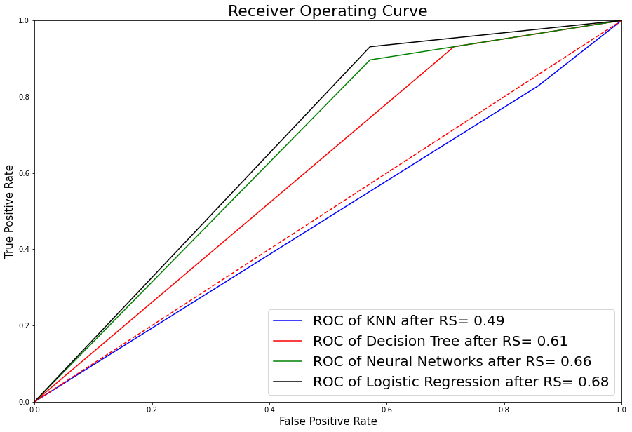

```python
import sklearn.metrics as metrics
roc_auc1=metrics.auc(fprknnrs,tprknnrs)
roc_auc2=metrics.auc(fprdtrs,tprdtrs)
roc_auc3=metrics.auc(fprnnrs,tprnnrs)
roc_auc4=metrics.auc(fprlrgrs,tprlrgrs)

# Method-I: PLot
import matplotlib.pyplot as plt
%matplotlib inline
plt.figure(figsize=(15,10))
plt.title("Receiver Operating Curve")
plt.plot(fprknnrs,tprknnrs,"b",label="ROC of KNN after RS= %0.2f" % roc_auc1)
plt.plot(fprdtrs,tprdtrs,"r",label="ROC of Decision Tree after RS= %0.2f" % roc_auc2)
plt.plot(fprnnrs,tprnnrs,"g",label="ROC of Neural Networks after RS= %0.2f" % roc_auc3)
plt.plot(fprlrgrs,tprlrgrs,"k",label="ROC of Logistic Regression after RS= %0.2f" % roc_auc4)
plt.rcParams.update({'font.size': 20})

plt.legend(loc="lower right")
plt.plot([0, 1],[0, 1],"r--")
plt.xlim([0, 1])
plt.ylim([0, 1])
plt.ylabel("True Positive Rate")
plt.xlabel("False Positive Rate")


plt.rc('axes', labelsize=15)
plt.rc('axes', titlesize=22)

# Print all ROC AUC scores
print("ROC AUC Scores after Randomized Search:")
print("KNN:", roc_auc1)
print("Decision Tree:", roc_auc2)
print("Neural Networks:", roc_auc3)
print("Logistic Regression:", roc_auc4)
```

### Insights:

After applying randomized search to tune hyperparameters, the ROC AUC scores for the classifiers are as follows:

KNN: 0.49 Decision Tree: 0.61 Neural Networks: 0.66 Logistic Regression: 0.68 These scores indicate the classifiers' abilities to discriminate between true positive and false positive rates, with higher scores reflecting better performance. Logistic Regression achieved the highest ROC AUC score, suggesting it may be the most effective classifier for predicting Hepatitis B infection in this context. However, Neural Networks also demonstrated competitive performance, indicating its potential as an alternative choice.

# Comparision of 4 algorithms before and after hyperparameter tuning

```python
algos1=["K Nearest Neighbor","Neural Networks","Decision Tree","Logistic Regression"]
acc1=[accknn,acc_nn_adam,accdt,acclrg]
recall1=[recallknn,recall_nn_adam,recalldt,recalllrg]
prec1=[precknn,prec_nn_adam,precdt,preclrg]
comp1={"Algorithms":algos1,"Accuracies before RS":acc1,"Recall before RS":recall1,"Precision before RS":prec1}
compdf1=pd.DataFrame(comp1)
display(compdf1.sort_values(by=["Accuracies before RS","Recall before RS","Precision before RS"], ascending=False))
acc2=[accknnrs,accnnrs,accdtrs,acclrgrs]
recall2=[recallknnrs,recallnnrs,recalldtrs,recalllrgrs]
prec2=[precknnrs,precnnrs,precdtrs,preclrgrs]
comp2={"Algorithms":algos1,"Accuracies after RS":acc2,"Recall after RS":recall2,"Precision after RS":prec2}
compdf2=pd.DataFrame(comp2)
display(compdf2.sort_values(by=["Accuracies after RS","Recall after RS","Precision after RS"], ascending=False))
```

|  | Algorithms | Accuracies before RS | Recall before RS | Precision before RS |
| --- | --- | --- | --- | --- |
| 3 | Logistic Regression | 83.333333 | 93.103448 | 87.096774 |
| 0 | K Nearest Neighbor | 77.777778 | 96.551724 | 80.000000 |
| 1 | Neural Networks | 77.777778 | 96.551724 | 80.000000 |
| 2 | Decision Tree | 75.000000 | 82.758621 | 85.714286 |

|  | Algorithms | Accuracies after RS | Recall after RS | Precision after RS |
| --- | --- | --- | --- | --- |
| 3 | Logistic Regression | 83.333333 | 93.103448 | 87.096774 |
| 2 | Decision Tree | 80.555556 | 93.103448 | 84.375000 |
| 1 | Neural Networks | 80.555556 | 89.655172 | 86.666667 |
| 0 | K Nearest Neighbor | 69.444444 | 82.758621 | 80.000000 |

### Insights:

Here are some insights based on the comparison of algorithms before and after applying randomized search for hyperparameter tuning:

#### Mixed Impact on K Nearest Neighbor:

K Nearest Neighbor (KNN) experiences a decrease in accuracy after randomized search, but it still maintains respectable recall and precision scores. This suggests that the hyperparameters chosen may not have been optimal for KNN, highlighting the importance of further experimentation.